# Hotel booking demands of a city and a resort hotel in Portugal

## Kinan Jemil Hassen

## Investigation

The objective of this investigation is to conduct an exploratory data analysis on a dataset containing booking information for a city hotel and a resort hotel. Both hotels are located in Portugal. Various characteristics of the bookings such as when the booking was made, length of stay, the number of adults, children, and/or babies, and the number of available parking spaces, among other things are included in the data. The time frame of the reservations included is between the 1st of July of 2015 and the 31st of August 2017.

## Dataset Overview

The dataset contains 117430 hotel reservations with 25 features that give further details on the bookings. Arrival date, hotel type, total length of stay, average daily rates, and customer type are some of the main features included.

## Classification by hotel types

As mentioned earlier during the dataset introduction, booking information for a city hotel and a resort hotel are included in this dataset. Both hotels are located in Portugal. The resort hotel is located in the resort region of Algarve and while the city hotel is in Lisbon. City hotels made up close to 2/3 of the data which is around 66.5% while resort hotels were 33.5% of the reservations.

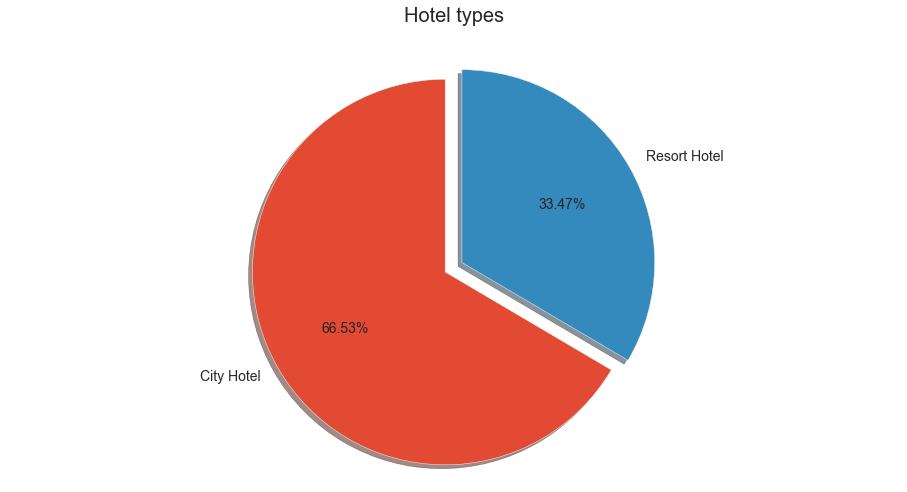

## Seasonal surge in reservations

It was evident that there tended to be an increase in reservations during the summer and fall season. There was an increase in reservations in the months Septmeber and October for the years 2015 and 2016. And for the year 2017, May and June were the most popular months.

Following further exploration, the results showed that was a gradual increase in reservations through out the years with a slight dip towards mid 2017. Overall, there were more reservations for city hotels than resort hotels.

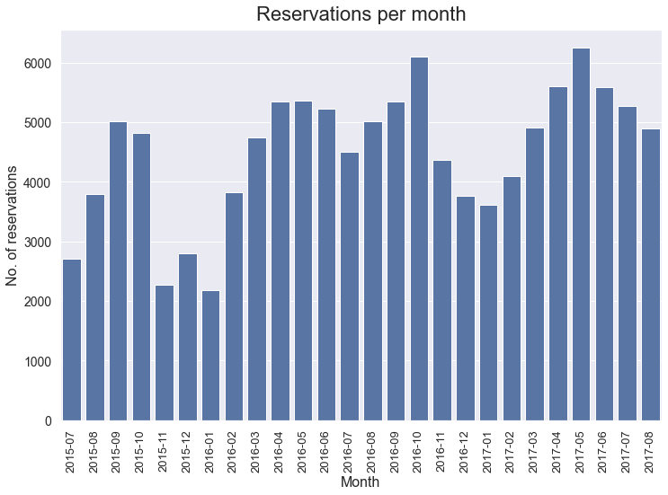

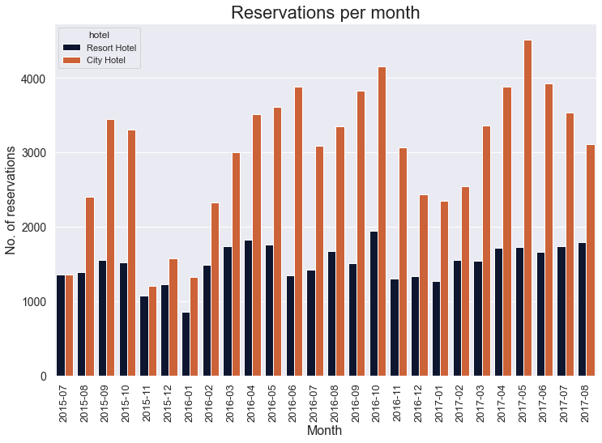

## Hotel rate vs length of stay

The bivariate exploration done on these two variables indicated that there was a very weak correlation between the length of stay and the average daily rates. The rates had close to no effect in the length of stay. Additional analysis done also supported the earlier finding where there was close to zero correlation between hotel rate and length of stay in both city and resort hotels.

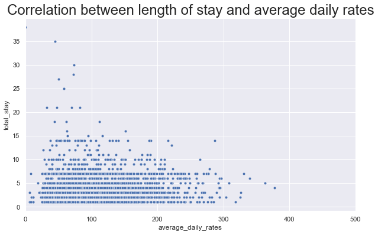

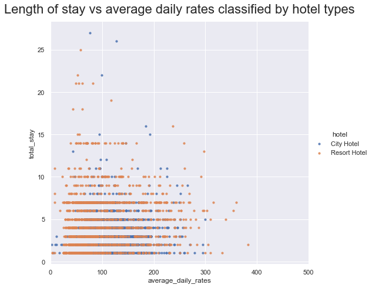

## Length of stay categorized by means of reservation

Customers that booked their reservations through Offline travel agents and tour operators stayed longer. On average, these customers stayed for 6 days. Guests that made the reservations themselves stayed only have as much which was around 3 days on average.

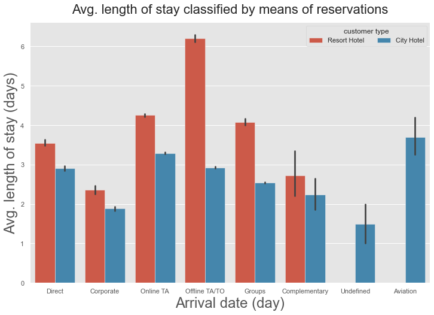

## Length of stay classified by hotel and customer types

In resort hotels, contract customer types tended to stay twice as long as compared to other customer types. However, in city hotels, Transient customers slightly stayed longer than the other types.

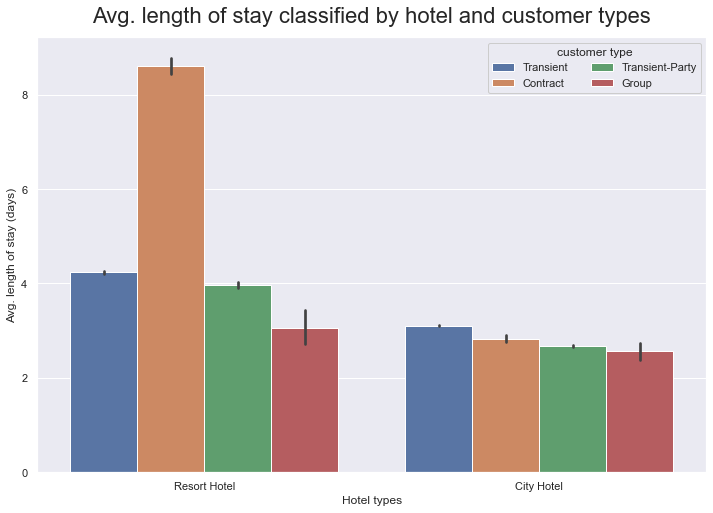

## Countries with the most number of guests

With regards to nationalities of the guests, around 85% of the reservations were made by the top 10 countries depicted in the visual below. Of these countries, Portugese nationals were the ones with most number of reservations followed by Great Britain and France.

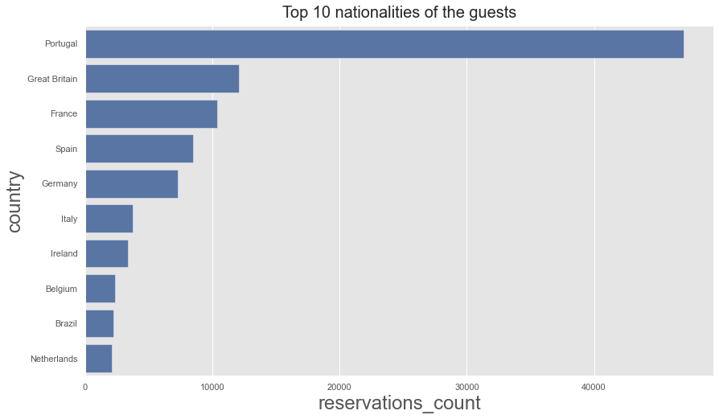